# Task 2 – Practicing data manipulation skills on images

a) Read image as a variable in R/Python. You need to install “jpeg” package to read image into a variable if you use R. For Python, an alternative is to use matplotlib package. What is the structure of the variable that stores the image? What is the dimension? a. Display the image. (Hint: google “rasterImage”)

```python
#Required libraries & packages
import numpy as np
import matplotlib.image as image
import matplotlib.pyplot as plt
```

```python
# Reading image & the structure of the variable that stores the image
image_p = plt.imread("Pinar_hw1.jpg")
image_p
```

```
array([[[ 52, 112, 172],
        [  8,  69, 136],
        [  0,  54, 129],
        ...,
        [ 71, 147, 183],
        [123, 179, 196],
        [214, 251, 255]],

       [[ 68, 128, 188],
        [ 25,  86, 153],
        [  9,  71, 146],
        ...,
        [ 80, 156, 192],
        [129, 185, 202],
        [218, 255, 255]],

       [[ 70, 130, 190],
        [ 28,  89, 154],
        [ 13,  75, 150],
        ...,
        [ 84, 160, 196],
        [132, 185, 203],
        [217, 254, 255]],

       ...,

       [[145, 155, 146],
        [113, 125, 115],
        [104, 117, 107],
        ...,
        [154, 166, 152],
        [181, 191, 180],
        [241, 251, 240]],

       [[144, 154, 145],
        [112, 124, 114],
        [104, 117, 107],
        ...,
        [156, 168, 154],
        [182, 192, 181],
        [241, 251, 240]],

       [[145, 155, 146],
        [115, 125, 116],
        [105, 118, 108],
        ...,
        [160, 172, 158],
        [185, 195, 184],
        [244, 254, 243]]], dtype=uint8)
```

```
(512, 512, 3)
```

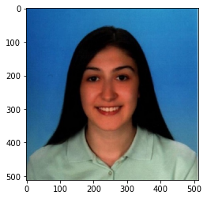

```python
# Dimension & & displaying image
print(image_p.shape)
plt.imshow(image_p)
```

b) Display each channel as separate image

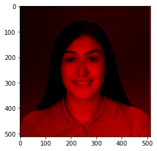

```python
# For red channel image

red_image = np.zeros(image_p.shape, dtype="uint8")
red_image[:,:,0] = image_p[:,:,0]
plt.imshow(red_image)
```

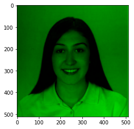

```python
# For green channell image
green_image = np.zeros(image_p.shape, dtype="uint8")
green_image[:,:,1] = image_p[:,:,1]
plt.imshow(green_image)
```

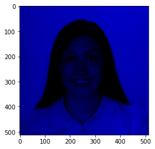

```python
# For blue channel image
blue_image = np.zeros(image_p.shape, dtype="uint8")
blue_image[:,:,2] = image_p[:,:,2]
plt.imshow(blue_image)
```

c) For each channel, take the average of the columns and plot the average as a line plot for each channel on a single plot.

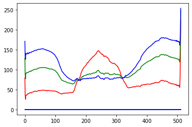

```python
#for red channel
redch_mean=np.mean(red_image, axis=0)
plt.plot(redch_mean, color="r")
#for green channel
greench_mean=np.mean(green_image, axis=0)
plt.plot(greench_mean, color="g")
#for blue channel
bluech_mean=np.mean(blue_image, axis=0)
plt.plot(bluech_mean, color="b")
```

d) For each channel, subtract one half of the image from the other half (choice of halves is up to you but dividing the head image vertically into two parts make more sense). If you observe negative pixel values, you can make them equal to zero. Then: • Display the new image. • Display each channel separately as separate image.

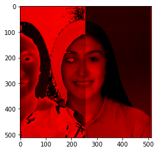

```python
# for red channel image manupilation
redch_lh=red_image[:,:256]
redch_rh=red_image[:,256:]
redch_lh=(redch_lh)-(redch_rh)
redch_lh=redch_lh.clip(min=0)
redch_final=np.concatenate((redch_lh,redch_rh),axis=1)
plt.imshow(redch_final)
```

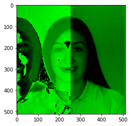

```python
# for green channel image manupilation
greench_lh=green_image[:,:256]
greench_rh=green_image[:,256:]
greench_lh=(greench_lh)-(greench_rh)
greench_lh=greench_lh.clip(min=0)
greench_final=np.concatenate((greench_lh,greench_rh),axis=1)
plt.imshow(greench_final)
```

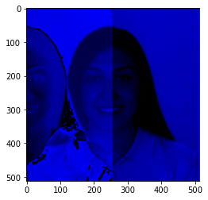

```python
# for blue channel image manupilation
bluech_lh=blue_image[:,:256]
bluech_rh=blue_image[:,256:]
bluech_lh=(bluech_lh)-(bluech_rh)
bluech_lh=bluech_lh.clip(min=0)
bluech_final=np.concatenate((bluech_lh,bluech_rh),axis=1)
plt.imshow(bluech_final)
```

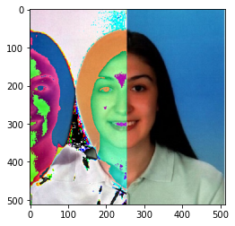

```python
# new image
new_image_p = np.zeros(image_p.shape, dtype="uint8")
new_image_p[:,:,0] = redch_final[:,:,0]
new_image_p[:,:,1] = greench_final[:,:,1]
new_image_p[:,:,2] = bluech_final[:,:,2]

plt.imshow(new_image_p)
```

e) In order to create a noisy image, add a random noise from uniform distribution with minimum value of 0 and a maximum value of “0.1 * maximum pixel value observed” to each pixel value for each channel of original image. • Display the new image. • Display each channel separately as separate image.

```python
# maximum values of pixel in image
print(np.max(red_image))
print(np.max(green_image))
print(np.max(blue_image))
```

```
245
255
255
```

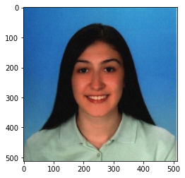

```python
# noise creation on the image
noise_func = np.random.uniform(0, 0.1*np.max(blue_image), size=(512, 512, 3))
noised_image=image_p+noise_func
noised_image=noised_image.clip(0,255)
noised_image=noised_image.astype(int)
plt.imshow(noised_image)
```

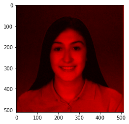

```python
# for noised red image
noised_red_image=np.zeros(noised_image.shape, dtype="uint8")
noised_red_image[:,:,0]=noised_image[:,:,0]
plt.imshow(noised_red_image)
```

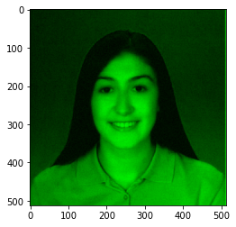

```python
# for noised green image
noised_green_image=np.zeros(noised_image.shape, dtype="uint8")
noised_green_image[:,:,1]=noised_image[:,:,0]
plt.imshow(noised_green_image)
```

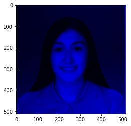

```python
# for noised blue image
noised_blue_image=np.zeros(noised_image.shape, dtype="uint8")
noised_blue_image[:,:,2]=noised_image[:,:,0]
plt.imshow(noised_blue_image)
```